# Practical Machine Learning: Prediction Exercise

Siddhesh Panhale

9/6/2020

#Background Using devices such as Jawbone Up, Nike FuelBand, and Fitbit it is now possible to collect a large amount of data about personal activity relatively inexpensively. These type of devices are part of the quantified self movement – a group of enthusiasts who take measurements about themselves regularly to improve their health, to find patterns in their behavior, or because they are tech geeks. One thing that people regularly do is quantify how much of a particular activity they do, but they rarely quantify how well they do it. In this project, your goal will be to use data from accelerometers on the belt, forearm, arm, and dumbell of 6 participants. They were asked to perform barbell lifts correctly and incorrectly in 5 different ways. More information is available from the website here: http://web.archive.org/web/20161224072740/http:/groupware.les.inf.puc-rio.br/har (see the section on the Weight Lifting Exercise Dataset).

#Data Loading and Exploratory Analysis

The training data for this project are available here:

https://d396qusza40orc.cloudfront.net/predmachlearn/pml-training.csv

The test data are available here:

https://d396qusza40orc.cloudfront.net/predmachlearn/pml-testing.csv

```r
library(dplyr)
```

```r
library(ggplot2)
library(knitr)
library(caret)
library(rpart)
library(rpart.plot)
library(rattle)
library(randomForest)
library(RColorBrewer)
library(RGtk2)
library(gbm)
training_Url<- "https://d396qusza40orc.cloudfront.net/predmachlearn/pml-training.csv"
testing_Url<- "https://d396qusza40orc.cloudfront.net/predmachlearn/pml-testing.csv"
training_data<- read.csv(url(training_Url))
testing_data<- read.csv(url(testing_Url))
dim(training_data)
```

```
## [1] 19622   160
```

```r
dim(testing_data)
```

```
## [1]  20 160
```

#Both datasets has 160 variables that has some NAs, that can be cleaned as below. This removes Near Zero variance(NZV) variables too.

```r
nzv <- nearZeroVar(training_data)

train_data <- training_data[,-nzv]
test_data <- testing_data[,-nzv]
dim(train_data)
```

```
## [1] 19622   100
```

```r
dim(test_data)
```

```
## [1]  20 100
```

```r
na_val_col <- sapply(train_data, function(x) mean(is.na(x))) > 0.95
train_data <- train_data[,na_val_col == FALSE]
test_data <- test_data[,na_val_col == FALSE]
dim(train_data)
```

```
## [1] 19622    59
```

```r
dim(test_data)
```

```
## [1] 20 59
```

#Removing non numeric variables

```r
train_data<- train_data[, 8:59]
test_data<- test_data[, 8:59]
dim(train_data)
```

```
## [1] 19622    52
```

```r
dim(test_data)
```

```
## [1] 20 52
```

##Data Partioning #Partitioning the data into two parts: 60% Training and 40% Testing

```r
inTrain<- createDataPartition(train_data$classe, p=0.6, list=FALSE)
inTrain<- createDataPartition(train_data$classe, p=0.6, list=FALSE)
training<- train_data[inTrain,]
testing<- train_data[-inTrain,]
dim(training)
```

```
## [1] 11776    52
```

```r
dim(testing)
```

```
## [1] 7846   52
```

##Prediction Model Building

#Decision Tree

[figure not shown]

```r
DT_model<- train(classe ~. , data=training, method= "rpart")
fancyRpartPlot(DT_model$finalModel)
```

```r
set.seed(21243)
DT_prediction<- predict(DT_model, testing)
confusionMatrix(table(DT_prediction, testing$classe))
```

```
## Confusion Matrix and Statistics
##
##
## DT_prediction    A    B    C    D    E
##             A 2056  655  654  585  344
##             B   31  504   59  227  284
##             C   97  154  535  185  200
##             D   45  205  120  289  205
##             E    3    0    0    0  409
##
## Overall Statistics
##
##                Accuracy : 0.4834
##                  95% CI : (0.4723, 0.4946)
##     No Information Rate : 0.2845
##     P-Value [Acc > NIR] : < 2.2e-16
##
##                   Kappa : 0.3233
##
##  Mcnemar's Test P-Value : < 2.2e-16
##
## Statistics by Class:
##
##                      Class: A Class: B Class: C Class: D Class: E
## Sensitivity            0.9211  0.33202  0.39108  0.22473  0.28363
## Specificity            0.6014  0.90503  0.90182  0.91235  0.99953
## Pos Pred Value         0.4788  0.45611  0.45687  0.33449  0.99272
## Neg Pred Value         0.9505  0.84958  0.87521  0.85720  0.86104
## Prevalence             0.2845  0.19347  0.17436  0.16391  0.18379
## Detection Rate         0.2620  0.06424  0.06819  0.03683  0.05213
## Detection Prevalence   0.5473  0.14084  0.14925  0.11012  0.05251
## Balanced Accuracy      0.7613  0.61852  0.64645  0.56854  0.64158
```

#Decision Tree Model we see the prediction accuracy is 48% which is not upto satisfactory level

#Random Forest MOdel

```r
set.seed(26817)
RF_model<- train(classe ~. , data=training, method= "rf", ntree=10)
RF_prediction<- predict(RF_model, testing)
RF_cm<-confusionMatrix(table(RF_prediction, testing$classe))
RF_cm
```

```
## Confusion Matrix and Statistics
##
##
## RF_prediction    A    B    C    D    E
##             A 2221   13    1    1    2
##             B    8 1485   22    3    5
##             C    1   12 1333   22    7
##             D    0    5   10 1257    5
##             E    2    3    2    3 1423
##
## Overall Statistics
##
##                Accuracy : 0.9838
##                  95% CI : (0.9808, 0.9865)
##     No Information Rate : 0.2845
##     P-Value [Acc > NIR] : <2e-16
##
##                   Kappa : 0.9795
##
##  Mcnemar's Test P-Value : 0.1772
##
## Statistics by Class:
##
##                      Class: A Class: B Class: C Class: D Class: E
## Sensitivity            0.9951   0.9783   0.9744   0.9774   0.9868
## Specificity            0.9970   0.9940   0.9935   0.9970   0.9984
## Pos Pred Value         0.9924   0.9750   0.9695   0.9843   0.9930
## Neg Pred Value         0.9980   0.9948   0.9946   0.9956   0.9970
## Prevalence             0.2845   0.1935   0.1744   0.1639   0.1838
## Detection Rate         0.2831   0.1893   0.1699   0.1602   0.1814
## Detection Prevalence   0.2852   0.1941   0.1752   0.1628   0.1826
## Balanced Accuracy      0.9960   0.9861   0.9840   0.9872   0.9926
```

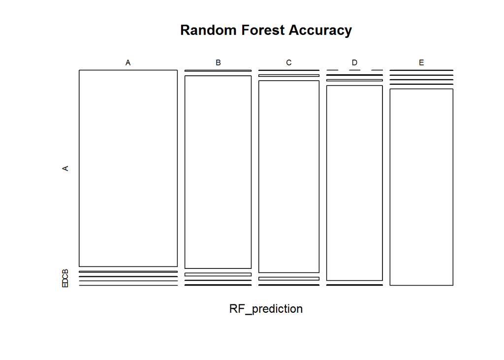

```r
plot(RF_cm$table, col=RF_cm$byClass, main="Random Forest Accuracy")
```

#Gradient Boosting Model

```r
set.seed(12345)
controlGBM <- trainControl(method = "repeatedcv", number = 5, repeats = 1)
GBM_model  <- train(classe ~ ., data=training, method = "gbm",
                    trControl = controlGBM, verbose = FALSE)
GBM_model$finalModel
```

```
## A gradient boosted model with multinomial loss function.
## 150 iterations were performed.
## There were 51 predictors of which 51 had non-zero influence.
```

```r
GBM_prediction <- predict(GBM_model, newdata=testing)
GBM_cm <- confusionMatrix(table(GBM_prediction, testing$classe))
GBM_cm
```

```
## Confusion Matrix and Statistics
##
##
## GBM_prediction    A    B    C    D    E
##              A 2195   37    0    1    4
##              B   31 1415   69   10   24
##              C    3   57 1271   45   17
##              D    2    2   24 1215   20
##              E    1    7    4   15 1377
##
## Overall Statistics
##
##                Accuracy : 0.9525
##                  95% CI : (0.9475, 0.9571)
##     No Information Rate : 0.2845
##     P-Value [Acc > NIR] : < 2.2e-16
##
##                   Kappa : 0.9399
##
##  Mcnemar's Test P-Value : 6.597e-05
##
## Statistics by Class:
##
##                      Class: A Class: B Class: C Class: D Class: E
## Sensitivity            0.9834   0.9321   0.9291   0.9448   0.9549
## Specificity            0.9925   0.9788   0.9812   0.9927   0.9958
## Pos Pred Value         0.9812   0.9135   0.9124   0.9620   0.9808
## Neg Pred Value         0.9934   0.9836   0.9850   0.9892   0.9899
## Prevalence             0.2845   0.1935   0.1744   0.1639   0.1838
## Detection Rate         0.2798   0.1803   0.1620   0.1549   0.1755
## Detection Prevalence   0.2851   0.1974   0.1775   0.1610   0.1789
## Balanced Accuracy      0.9880   0.9555   0.9551   0.9687   0.9754
```

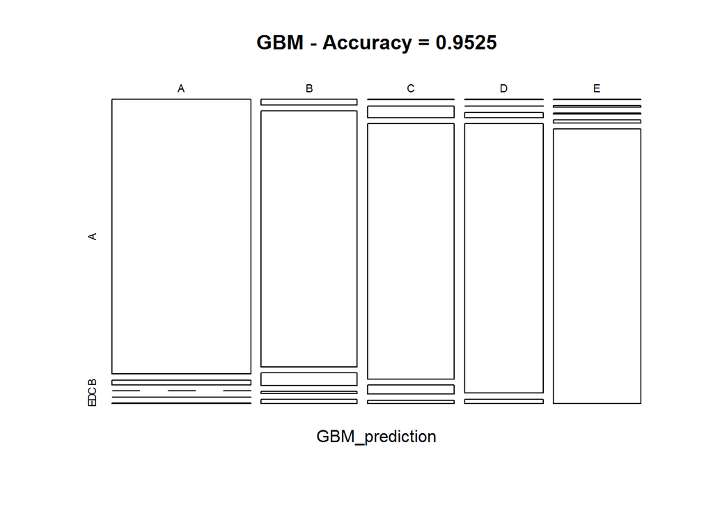

```r
plot(GBM_cm$table, col = GBM_cm$byClass,
     main = paste("GBM - Accuracy =", round(GBM_cm$overall['Accuracy'], 4)))
```

##compairing both models

```r
RF_cm$overall
```

```
##       Accuracy          Kappa  AccuracyLower  AccuracyUpper   AccuracyNull
##      0.9838134      0.9795236      0.9807707      0.9864886      0.2844762
## AccuracyPValue  McnemarPValue
##      0.0000000      0.1771630
```

```r
GBM_cm$overall
```

```
##       Accuracy          Kappa  AccuracyLower  AccuracyUpper   AccuracyNull
##   9.524599e-01   9.398582e-01   9.475168e-01   9.570632e-01   2.844762e-01
## AccuracyPValue  McnemarPValue
##   0.000000e+00   6.596765e-05
```

##Prediction using Random Forest Model on testing data.

```r
prediction_test<- predict(RF_model, test_data)
prediction_test
```

```
##  [1] B A B A A E D B A A B C B A E E A B B B
## Levels: A B C D E
```